# Cover letter

**Jerónimo Aranda Barois**

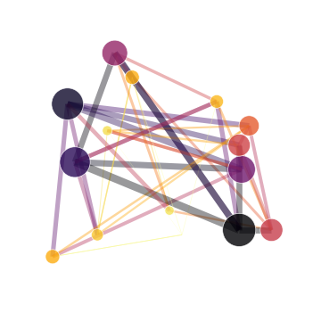

### What are your primary research interests and why do you think they are important?

I find **cognition** or in other words `computing` to be something really interesting to study, when building computing devices and designing architectures we sometimes forget some systems developed biollogically and organically by other kinds of life. I believe that if we really want to grasp what intelligence is, we should at least understand this different models, of course their substrates are different, and some do not even posess a nervous system, however they have proven to be robust and adaptable.

I would say the big jump to this kind of understanding comes from studying **dynamic networks**, systems that are made of agents, neurons or individuals that compute together but that their communication and their position changes, sometimes reffered to them as **liquid brains**. This systems experience **learning** in different ways, this can help us understand how our own heads were built and where its **plasticity** and robustness comes from. Bengio and Aguera y Arcas, researchers at **NeurIPS**, urged attendees to think more about the biological roots of natural intelligence, that will help us improve the machines we have.

```
"machines that learn in a very narrow way”
```

Understanding how dynamic learning networks develop and how they suddenly **solidify** can improve our recent efforts and broaden the AI limits, many problems that **nature** has already figured out. For example when it developed our **brains** through **evolution** and **cooperation** of single agents. This insights can help us when dealing with our **liquid society** issues and could help us survive and **evolve** as a whole.

### How would participating in the AI Residency help you to explore your research interests and achieve your goals?

When reading about past **AI residents** I see a great **diversity** of profiles, which for sure creates a great substract for creative ideas that soon become complete products, with many of them gaining impressive **scalability** and reach. I can imagine this to be an ambient for asking the biggest questions, those that involve **complex** systems where we soon find **computing limits**.

I believe Google to be a company that enjoys taking this kind of challenges, it has top industry researchers and infrastructure dedicated to exploring this limits on a **daily basis**, an exploration I would like to be part of specially with the big social challenges that are coming.

### Give an example of an open-ended research question or project you’ve worked on. What made it challenging and how did you overcome those challenges? Alternatively, summarize and critique a machine learning paper you have read that you found interesting.

**Visualization** is our biggest information input for understanding the world, that was my main inspiration when I decided to participate in a dataviz contest on visualizing Mexico City bike sharing system data, my roomate and I wanted to see if clear patterns emerged when watching this kind of network movements from above. This question was easily stated, but it needed **computer graphics** and **optimized data handling** knowledge to be answered.

Working in a team with Esteban, who is very skilled in data handling allowed me to improve my graphing skills and finally gave us the possibility to see the [patterns](https://vimeo.com/374568220). The flows of the city bikers that we could know see talked by themselves.

A recent **research paper** I read is:

- *Understanding Convolutional Neural Networks for Text Classification* by Alon Jacovi, Oren Sar Shalom and Yoav Goldberg.

Reading it was a very integral experience to me as it allowed one of the highest human skills, **text classification**, to be understood as a **linear algebra problem** another one of the highest human skills. It was not easy imagining the activation of artificial **neurons** that can **signal** words and even **contexts**. It can be confusing, however coming back to this paper and others really helped me during the **implementation** and fine tuning I had to do with these models.

I think that graphics showing the slots activation really helps in interpreting how this models work as I later could see, still this document sure gave me a better understanding on **speech** and how our most advanced language models work. It was very motivating as it was also my first real research experience in an industry context outside school.